# Evaluacion inicial de relaciones multivariadas (D_mod 2024-2025)

Edwin Silva Salas & Edwin Henao Ochoa

2026-08-03

# Etapa 3 — Evaluacion inicial de relaciones multivariadas (Seccion 5.3.8)

Dataset **$D_{\mathrm{mod}}$**: `data_agrupada_mod.csv` (cuadrante × semana, 2024–2025).

Complementa el analisis bivariado de la Seccion 5.3.7 evaluando **redundancia simultanea** entre covariables climaticas (VIF, PCA, agrupamiento jerarquico), asociacion parcial clima–respuesta y una regresion exploratoria de diagnostico. Objetivo: recomendar un subconjunto de predictoras y definir la variable respuesta para la Etapa 4.

Metodologia aplicada:

1. **VIF** del bloque climatico (multicolinealidad).
2. **PCA exploratorio** del bloque climatico (scree + loadings).
3. **Dendrograma** de variables climaticas por distancia de correlacion.
4. **Correlacion parcial** precipitacion–`n_eventos` controlando temperatura y viento.
5. **Regresion exploratoria** (diagnostico, no modelo final).
6. **PCA del bloque operativo** para dimensiones de impacto (frecuencia vs. duracion).

```r
library(tidyverse)
library(lubridate)
library(scales)
library(knitr)
env_path <- file.path("..", "..", ".env")
if (file.exists(".env")) {
  readRenviron(".env")
} else if (file.exists(env_path)) {
  readRenviron(env_path)
}

UBICACION_DATA <- Sys.getenv("UBICACION_DATA")
if (UBICACION_DATA == "") {
  stop("UBICACION_DATA no esta definida. Verifica el archivo .env.")
}

path_mod <- file.path(UBICACION_DATA, "data_agrupada_mod.csv")
path_full <- file.path(UBICACION_DATA, "data_agrupada.csv")

if (file.exists(path_mod)) {
  path_agrupada <- path_mod
  aplicar_filtro_anio <- FALSE
} else if (file.exists(path_full)) {
  path_agrupada <- path_full
  aplicar_filtro_anio <- TRUE
  warning("No se encontro data_agrupada_mod.csv; filtrando data_agrupada.csv a 2024-2025.")
} else {
  stop("No se encontro data_agrupada_mod.csv ni data_agrupada.csv.")
}

path_img_tesis <- file.path("..", "my-paper-overleaf", "img")
```

```r
guardar_plot <- function(plot, archivo, width, height) {
  ggsave(
    file.path(UBICACION_DATA, archivo),
    plot = plot,
    width = width,
    height = height,
    dpi = 300,
    bg = "white"
  )
  if (dir.exists(path_img_tesis)) {
    file.copy(
      file.path(UBICACION_DATA, archivo),
      file.path(path_img_tesis, archivo),
      overwrite = TRUE
    )
  }
}
```

```r
vars_operativo <- c(
  "n_eventos", "usuarios_afectados", "elementos_afectados", "duracion_total"
)

vars_clima <- c(
  "temp_media_semana", "temp_max_semana", "temp_min_semana",
  "humedad_media_semana", "viento_medio_semana", "viento_max_semana",
  "precip_total_semana"
)

etiquetas_vars <- c(
  temp_media_semana = "temp_media",
  temp_max_semana = "temp_max",
  temp_min_semana = "temp_min",
  humedad_media_semana = "humedad",
  viento_medio_semana = "viento_medio",
  viento_max_semana = "viento_max",
  precip_total_semana = "precip_total",
  n_eventos = "n_eventos",
  usuarios_afectados = "usuarios_afectados",
  elementos_afectados = "elementos_afectados",
  duracion_total = "duracion_total"
)

calcular_vif <- function(data, variables, response = "n_eventos") {
  vars_ok <- variables[variables %in% names(data)]
  fmla <- as.formula(
    paste(response, "~", paste(vars_ok, collapse = " + "))
  )
  modelo <- lm(fmla, data = data)
  vif_vals <- car::vif(modelo)
  if (is.matrix(vif_vals)) {
    vif_vals <- vif_vals[, 1]
  }
  tibble(
    variable = names(vif_vals),
    vif = round(as.numeric(vif_vals), 2)
  ) %>%
    arrange(desc(vif))
}
```

```r
message("Leyendo D_mod...")
```

```
## Leyendo D_mod...
```

```r
d_mod <- read_csv(path_agrupada, show_col_types = FALSE)

if ("semana" %in% names(d_mod) && !inherits(d_mod$semana, "Date")) {
  d_mod <- d_mod %>% mutate(semana = as.Date(semana))
}

d_mod <- if (aplicar_filtro_anio) {
  d_mod %>% filter(year(semana) %in% 2024:2025)
} else {
  d_mod
}

d_evento <- d_mod %>% filter(n_eventos > 0)

kable(
  tibble(
    metrica = c("Filas panel", "Filas con evento", "% con evento"),
    valor = c(
      nrow(d_mod),
      nrow(d_evento),
      paste0(round(100 * nrow(d_evento) / nrow(d_mod), 1), "%")
    )
  ),
  col.names = c("Metrica", "Valor")
)
```

| Metrica | Valor |
| --- | --- |
| Filas panel | 36120 |
| Filas con evento | 13351 |
| % con evento | 37% |

## 1. Multicolinealidad climatica (VIF)

Se ajusta un modelo lineal auxiliar `n_eventos ~ variables climaticas` para calcular el VIF de cada covariable (diagnostico de multicolinealidad en el contexto predictivo).

```r
if (!requireNamespace("car", quietly = TRUE)) {
  install.packages("car", repos = "https://cloud.r-project.org")
}
library(car)
vif_clima <- calcular_vif(d_mod, vars_clima, response = "n_eventos")
vif_clima <- vif_clima %>%
  mutate(
    etiqueta = etiquetas_vars[variable],
    alerta = case_when(
      vif >= 10 ~ "Alta (>=10)",
      vif >= 5 ~ "Moderada (>=5)",
      TRUE ~ "Baja (<5)"
    )
  )

kable(
  vif_clima %>% select(variable, vif, alerta),
  col.names = c("Variable", "VIF", "Nivel"),
  caption = "VIF del bloque climatico (modelo auxiliar n_eventos ~ clima)"
)
```

VIF del bloque climatico (modelo auxiliar n_eventos ~ clima)

| Variable | VIF | Nivel |
| --- | --- | --- |
| temp_media_semana | 43.92 | Alta (>=10) |
| viento_medio_semana | 24.22 | Alta (>=10) |
| viento_max_semana | 22.58 | Alta (>=10) |
| temp_max_semana | 17.27 | Alta (>=10) |
| temp_min_semana | 14.37 | Alta (>=10) |
| humedad_media_semana | 5.68 | Moderada (>=5) |
| precip_total_semana | 1.50 | Baja (<5) |

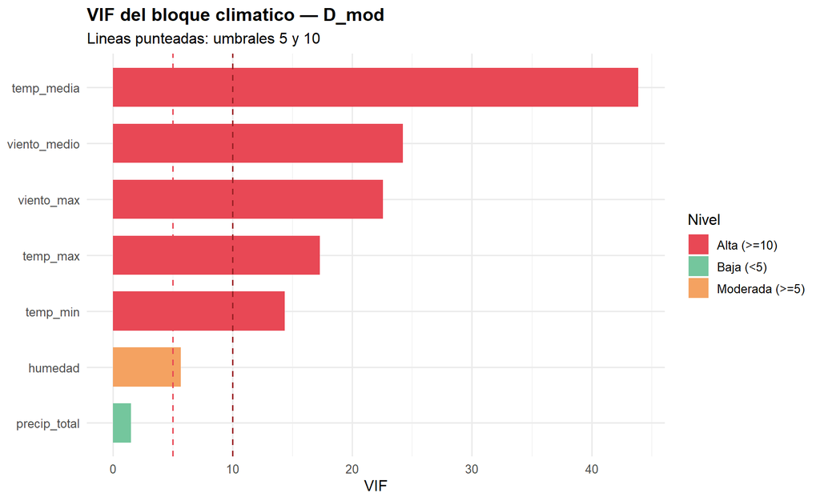

```r
p_vif <- ggplot(vif_clima, aes(x = reorder(etiqueta, vif), y = vif, fill = alerta)) +
  geom_col(width = 0.7, show.legend = TRUE) +
  geom_hline(yintercept = 5, linetype = "dashed", color = "#E84855", linewidth = 0.7) +
  geom_hline(yintercept = 10, linetype = "dashed", color = "#9B2226", linewidth = 0.7) +
  coord_flip() +
  scale_fill_manual(values = c(
    "Baja (<5)" = "#74C69D",
    "Moderada (>=5)" = "#F4A261",
    "Alta (>=10)" = "#E84855"
  )) +
  labs(
    title = "VIF del bloque climatico — D_mod",
    subtitle = "Lineas punteadas: umbrales 5 y 10",
    x = NULL, y = "VIF", fill = "Nivel"
  ) +
  theme_minimal(base_size = 12) +
  theme(plot.title = element_text(face = "bold"))

p_vif
```

```r
guardar_plot(p_vif, "vif_clima_multivariado_mod.png", 9, 5.5)
```

```
## [1] TRUE
```

### VIF con subconjunto reducido

```r
vars_clima_reducido <- c(
  "precip_total_semana", "temp_media_semana",
  "humedad_media_semana", "viento_medio_semana"
)

vif_reducido <- calcular_vif(d_mod, vars_clima_reducido, response = "n_eventos")
kable(vif_reducido, col.names = c("Variable", "VIF"),
      caption = "VIF con subconjunto climatico reducido propuesto")
```

VIF con subconjunto climatico reducido propuesto

| Variable | VIF |
| --- | --- |
| temp_media_semana | 7.21 |
| humedad_media_semana | 4.47 |
| viento_medio_semana | 3.27 |
| precip_total_semana | 1.49 |

## 2. PCA exploratorio del bloque climatico

```r
clima_mat <- d_mod %>%
  select(all_of(vars_clima)) %>%
  drop_na() %>%
  scale()

pca_clima <- prcomp(clima_mat, center = FALSE, scale. = FALSE)

var_explicada <- (pca_clima$sdev^2) / sum(pca_clima$sdev^2)
tabla_pca <- tibble(
  componente = paste0("PC", seq_along(var_explicada)),
  varianza_pct = round(100 * var_explicada, 1),
  varianza_acum_pct = round(100 * cumsum(var_explicada), 1)
)

kable(tabla_pca, col.names = c("Componente", "Varianza (%)", "Acumulada (%)"))
```

| Componente | Varianza (%) | Acumulada (%) |
| --- | --- | --- |
| PC1 | 66.9 | 66.9 |
| PC2 | 20.4 | 87.3 |
| PC3 | 8.3 | 95.6 |
| PC4 | 2.5 | 98.1 |
| PC5 | 1.4 | 99.5 |
| PC6 | 0.3 | 99.8 |
| PC7 | 0.2 | 100.0 |

```r
loadings <- as.data.frame(pca_clima$rotation[, 1:3, drop = FALSE]) %>%
  rownames_to_column("variable") %>%
  pivot_longer(-variable, names_to = "componente", values_to = "loading") %>%
  mutate(etiqueta = etiquetas_vars[variable])
```

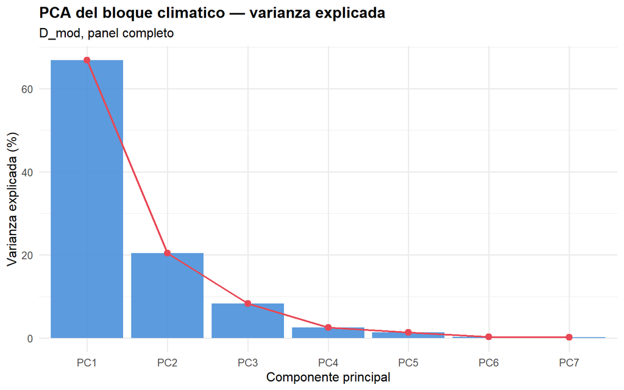

```r
df_scree <- tabla_pca %>%
  mutate(componente = factor(componente, levels = componente))

p_scree <- ggplot(df_scree, aes(x = componente, y = varianza_pct)) +
  geom_col(fill = "#4A90D9", alpha = 0.9) +
  geom_line(aes(group = 1), linewidth = 0.8, color = "#E84855") +
  geom_point(size = 2.5, color = "#E84855") +
  labs(
    title = "PCA del bloque climatico — varianza explicada",
    subtitle = "D_mod, panel completo",
    x = "Componente principal", y = "Varianza explicada (%)"
  ) +
  theme_minimal(base_size = 12) +
  theme(plot.title = element_text(face = "bold"))

p_scree
```

```r
guardar_plot(p_scree, "pca_scree_clima_multivariado_mod.png", 8, 5)
```

```
## [1] TRUE
```

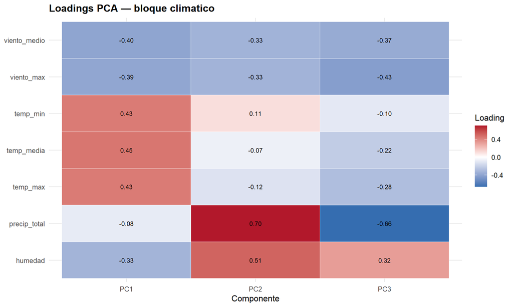

```r
p_loadings <- ggplot(loadings, aes(x = componente, y = etiqueta, fill = loading)) +
  geom_tile(color = "white") +
  geom_text(aes(label = sprintf("%.2f", loading)), size = 3.2) +
  scale_fill_gradient2(low = "#2166AC", mid = "white", high = "#B2182B", midpoint = 0) +
  labs(
    title = "Loadings PCA — bloque climatico",
    x = "Componente", y = NULL, fill = "Loading"
  ) +
  theme_minimal(base_size = 12) +
  theme(plot.title = element_text(face = "bold"))

p_loadings
```

```r
guardar_plot(p_loadings, "pca_loadings_clima_multivariado_mod.png", 10, 6)
```

```
## [1] TRUE
```

## 3. Agrupamiento jerarquico de variables climaticas

```r
cor_clima <- cor(d_mod %>% select(all_of(vars_clima)), method = "spearman", use = "pairwise.complete.obs")
dist_clima <- as.dist(1 - abs(cor_clima))

png(
  file.path(UBICACION_DATA, "dendrograma_clima_multivariado_mod.png"),
  width = 9, height = 5.5, units = "in", res = 300
)
hc <- hclust(dist_clima, method = "average")
plot(
  hc,
  main = "Dendrograma de variables climaticas (distancia = 1 - |rho Spearman|)",
  xlab = "", sub = "D_mod, 2024-2025",
  labels = etiquetas_vars[hc$label]
)
dev.off()
```

```r
if (dir.exists(path_img_tesis)) {
  file.copy(
    file.path(UBICACION_DATA, "dendrograma_clima_multivariado_mod.png"),
    file.path(path_img_tesis, "dendrograma_clima_multivariado_mod.png"),
    overwrite = TRUE
  )
}
```

```
## [1] TRUE
```

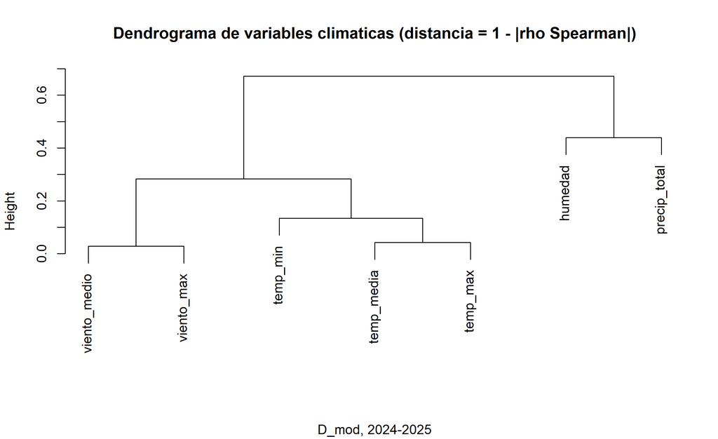

```r
knitr::include_graphics(file.path(path_img_tesis, "dendrograma_clima_multivariado_mod.png"))
```

## 4. Correlacion parcial y regresion exploratoria

Correlacion parcial de Spearman entre `precip_total_semana` y `n_eventos`, controlando `temp_media_semana` y `viento_medio_semana` (residuos de rangos).

```r
partial_spearman <- function(data, x, y, controls) {
  rank_data <- data %>%
    select(all_of(c(x, y, controls))) %>%
    drop_na() %>%
    mutate(across(everything(), rank))

  resid_x <- lm(as.formula(paste(x, "~", paste(controls, collapse = " + "))), data = rank_data)$residuals
  resid_y <- lm(as.formula(paste(y, "~", paste(controls, collapse = " + "))), data = rank_data)$residuals
  cor(resid_x, resid_y, method = "pearson")
}

rho_parcial <- partial_spearman(
  d_mod,
  "precip_total_semana",
  "n_eventos",
  c("temp_media_semana", "viento_medio_semana")
)

rho_bivariado <- cor(
  d_mod$precip_total_semana,
  d_mod$n_eventos,
  use = "complete.obs",
  method = "spearman"
)

kable(
  tibble(
    tipo = c("Bivariado Spearman", "Parcial (control temp + viento)"),
    rho = round(c(rho_bivariado, rho_parcial), 3)
  ),
  col.names = c("Tipo", "rho precip vs n_eventos")
)
```

| Tipo | rho precip vs n_eventos |
| --- | --- |
| Bivariado Spearman | 0.065 |
| Parcial (control temp + viento) | 0.114 |

Regresion exploratoria Poisson (diagnostico) con subconjunto climatico reducido:

```r
if (!requireNamespace("broom", quietly = TRUE)) {
  install.packages("broom", repos = "https://cloud.r-project.org")
}
library(broom)
d_reg <- d_mod %>%
  mutate(
    log_precip = log1p(precip_total_semana),
    temp_media_z = as.numeric(scale(temp_media_semana)),
    humedad_z = as.numeric(scale(humedad_media_semana)),
    viento_z = as.numeric(scale(viento_medio_semana))
  )

mod_poisson <- glm(
  n_eventos ~ log_precip + temp_media_z + humedad_z + viento_z,
  family = poisson(),
  data = d_reg
)

coef_tabla <- broom::tidy(mod_poisson) %>%
  mutate(
    estimate = round(estimate, 4),
    std.error = round(std.error, 4),
    p.value = signif(p.value, 3)
  )

kable(
  coef_tabla %>% select(term, estimate, std.error, p.value),
  col.names = c("Termino", "Coeficiente", "Error est.", "p-valor"),
  caption = "GLM Poisson exploratorio: n_eventos ~ clima reducido"
)
```

GLM Poisson exploratorio: n_eventos ~ clima reducido

| Termino | Coeficiente | Error est. | p-valor |
| --- | --- | --- | --- |
| (Intercept) | -0.4883 | 0.0188 | 0 |
| log_precip | 0.1252 | 0.0069 | 0 |
| temp_media_z | 0.8084 | 0.0153 | 0 |
| humedad_z | 0.3502 | 0.0129 | 0 |
| viento_z | 0.7259 | 0.0091 | 0 |

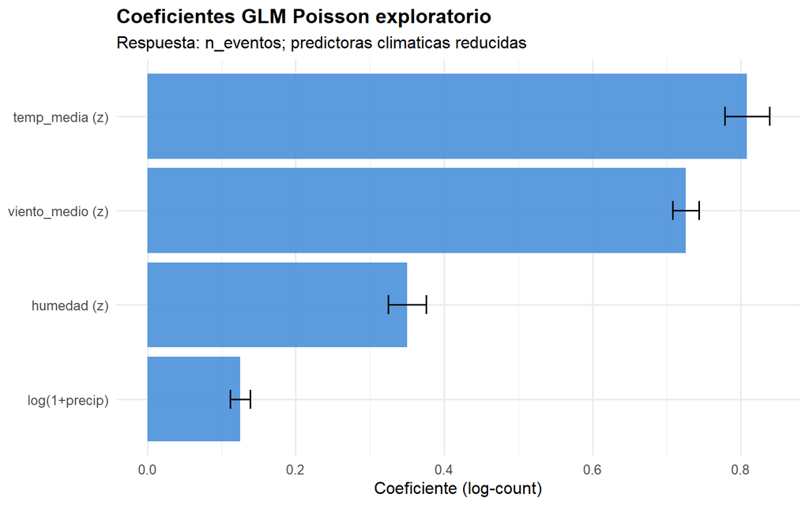

```r
coef_plot <- coef_tabla %>%
  filter(term != "(Intercept)") %>%
  mutate(
    term = case_when(
      term == "log_precip" ~ "log(1+precip)",
      term == "temp_media_z" ~ "temp_media (z)",
      term == "humedad_z" ~ "humedad (z)",
      term == "viento_z" ~ "viento_medio (z)",
      TRUE ~ term
    )
  )

p_coef <- ggplot(coef_plot, aes(x = reorder(term, estimate), y = estimate)) +
  geom_col(fill = "#4A90D9", alpha = 0.9) +
  geom_errorbar(aes(ymin = estimate - 1.96 * std.error, ymax = estimate + 1.96 * std.error), width = 0.2) +
  coord_flip() +
  labs(
    title = "Coeficientes GLM Poisson exploratorio",
    subtitle = "Respuesta: n_eventos; predictoras climaticas reducidas",
    x = NULL, y = "Coeficiente (log-count)"
  ) +
  theme_minimal(base_size = 12) +
  theme(plot.title = element_text(face = "bold"))

p_coef
```

```r
guardar_plot(p_coef, "glm_coef_clima_multivariado_mod.png", 8, 5)
```

```
## [1] TRUE
```

## 5. PCA del bloque operativo (dimensiones de impacto)

```r
oper_mat <- d_mod %>%
  select(all_of(vars_operativo)) %>%
  mutate(across(everything(), ~ log1p(.))) %>%
  scale()

pca_oper <- prcomp(oper_mat, center = FALSE, scale. = FALSE)
var_oper <- (pca_oper$sdev^2) / sum(pca_oper$sdev^2)

tabla_pca_oper <- tibble(
  componente = paste0("PC", seq_along(var_oper)),
  varianza_pct = round(100 * var_oper, 1),
  varianza_acum_pct = round(100 * cumsum(var_oper), 1)
)

kable(tabla_pca_oper, col.names = c("Componente", "Varianza (%)", "Acumulada (%)"))
```

| Componente | Varianza (%) | Acumulada (%) |
| --- | --- | --- |
| PC1 | 83.8 | 83.8 |
| PC2 | 11.9 | 95.7 |
| PC3 | 3.3 | 99.0 |
| PC4 | 1.0 | 100.0 |

```r
loadings_oper <- as.data.frame(pca_oper$rotation[, 1:2, drop = FALSE]) %>%
  rownames_to_column("variable") %>%
  pivot_longer(-variable, names_to = "componente", values_to = "loading") %>%
  mutate(etiqueta = etiquetas_vars[variable])
```

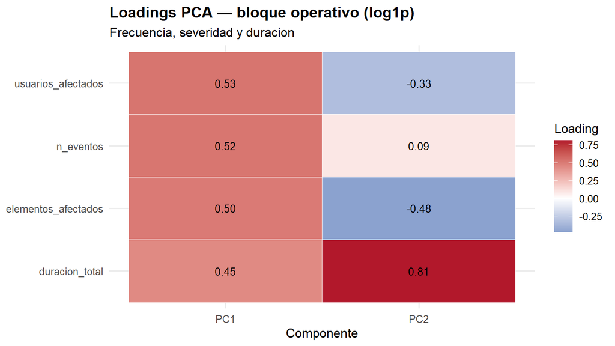

```r
p_loadings_oper <- ggplot(loadings_oper, aes(x = componente, y = etiqueta, fill = loading)) +
  geom_tile(color = "white") +
  geom_text(aes(label = sprintf("%.2f", loading)), size = 3.5) +
  scale_fill_gradient2(low = "#2166AC", mid = "white", high = "#B2182B", midpoint = 0) +
  labs(
    title = "Loadings PCA — bloque operativo (log1p)",
    subtitle = "Frecuencia, severidad y duracion",
    x = "Componente", y = NULL, fill = "Loading"
  ) +
  theme_minimal(base_size = 12) +
  theme(plot.title = element_text(face = "bold"))

p_loadings_oper
```

```r
guardar_plot(p_loadings_oper, "pca_loadings_operativo_multivariado_mod.png", 8, 4.5)
```

```
## [1] TRUE
```

## 6. Sintesis y recomendaciones para Etapa 4

```r
recomendacion <- tibble(
  decision = c(
    "Predictoras climaticas",
    "Variable respuesta frecuencia",
    "Variable respuesta continuidad",
    "Variables a excluir por redundancia",
    "Senal multivariada precipitacion"
  ),
  recomendacion = c(
    paste(vars_clima_reducido, collapse = ", "),
    "n_eventos (proxy SAIFI)",
    "duracion_total (proxy SAIDI)",
    "temp_max, temp_min, viento_max (VIF elevado con sus pares)",
    paste0(
      "rho parcial precip-n_eventos = ", round(rho_parcial, 3),
      " (bivariado = ", round(rho_bivariado, 3), ")"
    )
  )
)

kable(recomendacion, col.names = c("Decision", "Recomendacion EDA"))
```

| Decision | Recomendacion EDA |
| --- | --- |
| Predictoras climaticas | precip_total_semana, temp_media_semana, humedad_media_semana, viento_medio_semana |
| Variable respuesta frecuencia | n_eventos (proxy SAIFI) |
| Variable respuesta continuidad | duracion_total (proxy SAIDI) |
| Variables a excluir por redundancia | temp_max, temp_min, viento_max (VIF elevado con sus pares) |
| Senal multivariada precipitacion | rho parcial precip-n_eventos = 0.114 (bivariado = 0.065) |

Los resultados orientan la Etapa 4: depuracion cuantitativa con subconjunto climatico reducido, definicion explicita de `n_eventos` como respuesta de frecuencia, construccion de ventanas temporales y estandarizacion previa al modelado predictivo.